# Machine Learning - Classe prediction

Andrea Fatutta

19 april 2017

## Synopsis

In this assignment we will explore and analyze some data about fitness training of different subjects that has been collected using smart devices such *Jawbone Up, Nike FuelBand, and Fitbit*.

The goal is to be able to classify with the lowest possible margin of error the class of each excercise that has been recorded and submit the result of the predictions to be evaluated.

*Source: Ugulino, W.; Cardador, D.; Vega, K.; Velloso, E.; Milidiu, R.; Fuks, H. Wearable Computing: Accelerometers’ Data Classification of Body Postures and Movements. Proceedings of 21st Brazilian Symposium on Artificial Intelligence. Advances in Artificial Intelligence - SBIA 2012. In: Lecture Notes in Computer Science. , pp. 52-61. Curitiba, PR: Springer Berlin / Heidelberg, 2012. ISBN 978-3-642-34458-9. DOI: 10.1007/978-3-642-34459-6_6.*

*Link: http://groupware.les.inf.puc-rio.br/har*

## Data processing

In this section data will be loaded and explored, below a brief summary of the data structure, once it has been cleaned up for NA values and data that we will not use for prediction.

The basic data set contains 19622 observation and 160 variables, therefore it will be hard to show even some rows in this document, but we can have a look at the “classe” variable that is what we need to predict.

```
##    A    B    C    D    E
## 5580 3797 3422 3216 3607
```

We can see that this variable contains 5 specific levels and therefore we will use some classification algorhythms that will allow us to use the continuos variables, i.e. acceleration, position, etc, to predict a discrete categorization for the class.

At first we need to clean up the first 7 columns that contains informations about the data gathering and the columns that contains many NA values; all this columns therefore are not usable for prediction.

The final clean data set contains 19622 observation and 53 variables, below a plot of the frequency for the 5 classe types.

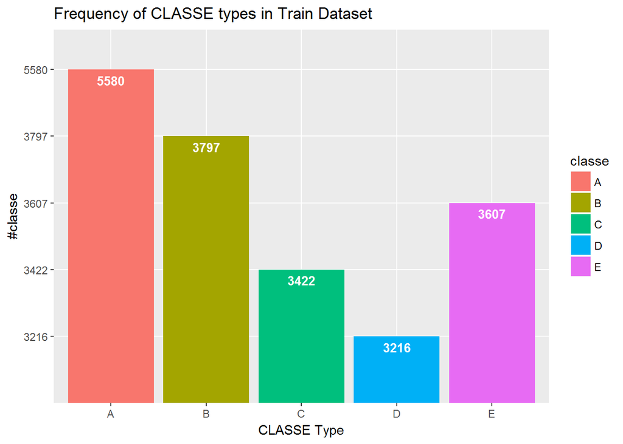

## Model selection/training

Training data has been splitted in 2 parts, 75% for model training and 25% for results checking.

I will use some models that has been presented during the course and others that I found on the web that are used for this purpose:

1. Recursive Partitioning and Regression Trees ( with “rpart” library) https://en.wikipedia.org/wiki/Recursive_partitioning
2. Random Forest ( with “randomForest” library) https://en.wikipedia.org/wiki/Random_forest
3. Naive Bayes ( with “e1071” library) https://en.wikipedia.org/wiki/Naive_Bayes_classifier
4. Support Vector Machines ( with “e1071” library) https://en.wikipedia.org/wiki/Support_vector_machine

### Recursive Partitioning and Regression Trees

```r
# Fit model - regression tree
fitRpart <- rpart(classe ~ ., data=trainDataSet, method="class")

# Perform prediction
predictRpart <- predict(fitRpart, trainDataControl, type = "class")
```

Here the plot of the tree classifications against all the remaining variables:

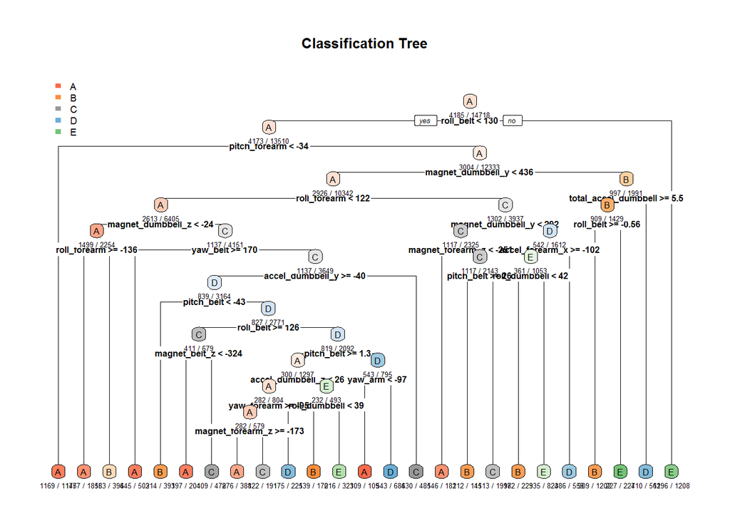

```r
# Plot result
rpart.plot(fitRpart, main="Classification Tree", extra=2, under=TRUE, cex=0.5 )
```

This is the confusion matrix for the predicted values against the original ones:

```r
cmRpart<-confusionMatrix(predictRpart, trainDataControl$classe)
cmRpart
```

```
## Confusion Matrix and Statistics
##
##           Reference
## Prediction    A    B    C    D    E
##          A 1281  139   16   40   17
##          B   44  585   46   60   73
##          C   33   90  679  119  115
##          D   18   62   61  521   44
##          E   19   73   53   64  652
##
## Overall Statistics
##
##                Accuracy : 0.7582
##                  95% CI : (0.7459, 0.7701)
##     No Information Rate : 0.2845
##     P-Value [Acc > NIR] : < 2.2e-16
##
##                   Kappa : 0.6934
##  Mcnemar's Test P-Value : < 2.2e-16
##
## Statistics by Class:
##
##                      Class: A Class: B Class: C Class: D Class: E
## Sensitivity            0.9183   0.6164   0.7942   0.6480   0.7236
## Specificity            0.9396   0.9436   0.9118   0.9549   0.9478
## Pos Pred Value         0.8580   0.7240   0.6554   0.7380   0.7573
## Neg Pred Value         0.9666   0.9111   0.9545   0.9326   0.9384
## Prevalence             0.2845   0.1935   0.1743   0.1639   0.1837
## Detection Rate         0.2612   0.1193   0.1385   0.1062   0.1330
## Detection Prevalence   0.3044   0.1648   0.2113   0.1440   0.1756
## Balanced Accuracy      0.9289   0.7800   0.8530   0.8014   0.8357
```

### Random Forest

Here the confusion matrix for this model:

```r
fitRForest <- randomForest(classe ~ ., data=trainDataSet, method="class")

# Perform prediction
predictRForest <- predict(fitRForest, trainDataControl, type = "class")

##confusion matrix

cmForest <- confusionMatrix(predictRForest, trainDataControl$classe)
cmForest
```

```
## Confusion Matrix and Statistics
##
##           Reference
## Prediction    A    B    C    D    E
##          A 1394    5    0    0    0
##          B    0  942    6    0    0
##          C    0    2  849    5    0
##          D    0    0    0  797    3
##          E    1    0    0    2  898
##
## Overall Statistics
##
##                Accuracy : 0.9951
##                  95% CI : (0.9927, 0.9969)
##     No Information Rate : 0.2845
##     P-Value [Acc > NIR] : < 2.2e-16
##
##                   Kappa : 0.9938
##  Mcnemar's Test P-Value : NA
##
## Statistics by Class:
##
##                      Class: A Class: B Class: C Class: D Class: E
## Sensitivity            0.9993   0.9926   0.9930   0.9913   0.9967
## Specificity            0.9986   0.9985   0.9983   0.9993   0.9993
## Pos Pred Value         0.9964   0.9937   0.9918   0.9963   0.9967
## Neg Pred Value         0.9997   0.9982   0.9985   0.9983   0.9993
## Prevalence             0.2845   0.1935   0.1743   0.1639   0.1837
## Detection Rate         0.2843   0.1921   0.1731   0.1625   0.1831
## Detection Prevalence   0.2853   0.1933   0.1746   0.1631   0.1837
## Balanced Accuracy      0.9989   0.9956   0.9956   0.9953   0.9980
```

### Naive Bayes

Here the confusion matrix for this model:

```r
##fit creation
fitNB <- naiveBayes(classe~.,data = trainDataSet)

##Perform prediction
predictNB <- predict(fitNB, trainDataControl, type = "class")

##confusion matrix
cmNB<-confusionMatrix(predictNB, trainDataControl$classe)
cmNB
```

```
## Confusion Matrix and Statistics
##
##           Reference
## Prediction   A   B   C   D   E
##          A 907 126 174  71  47
##          B  64 559  98  31 180
##          C 230 144 424 241 101
##          D 157  61  98 360 104
##          E  37  59  61 101 469
##
## Overall Statistics
##
##                Accuracy : 0.5544
##                  95% CI : (0.5404, 0.5684)
##     No Information Rate : 0.2845
##     P-Value [Acc > NIR] : < 2.2e-16
##
##                   Kappa : 0.4378
##  Mcnemar's Test P-Value : < 2.2e-16
##
## Statistics by Class:
##
##                      Class: A Class: B Class: C Class: D Class: E
## Sensitivity            0.6502   0.5890  0.49591  0.44776  0.52053
## Specificity            0.8809   0.9057  0.82317  0.89756  0.93555
## Pos Pred Value         0.6845   0.5998  0.37193  0.46154  0.64512
## Neg Pred Value         0.8636   0.9018  0.88549  0.89234  0.89658
## Prevalence             0.2845   0.1935  0.17435  0.16395  0.18373
## Detection Rate         0.1850   0.1140  0.08646  0.07341  0.09564
## Detection Prevalence   0.2702   0.1900  0.23246  0.15905  0.14825
## Balanced Accuracy      0.7655   0.7474  0.65954  0.67266  0.72804
```

### Support Vector Machines

Here the confusion matrix for this model:

```r
##fit creation
fitSVM <- svm(classe~.,data = trainDataSet)

##Perform prediction
predictSVM <- predict(fitSVM, trainDataControl, type = "class")

##confusion matrix
cmSVM<-confusionMatrix(predictSVM, trainDataControl$classe)
cmSVM
```

```
## Confusion Matrix and Statistics
##
##           Reference
## Prediction    A    B    C    D    E
##          A 1388   70    2    2    0
##          B    1  860   24    0    1
##          C    5   19  817   80   20
##          D    0    0   10  721   20
##          E    1    0    2    1  860
##
## Overall Statistics
##
##                Accuracy : 0.9474
##                  95% CI : (0.9408, 0.9535)
##     No Information Rate : 0.2845
##     P-Value [Acc > NIR] : < 2.2e-16
##
##                   Kappa : 0.9333
##  Mcnemar's Test P-Value : NA
##
## Statistics by Class:
##
##                      Class: A Class: B Class: C Class: D Class: E
## Sensitivity            0.9950   0.9062   0.9556   0.8968   0.9545
## Specificity            0.9789   0.9934   0.9694   0.9927   0.9990
## Pos Pred Value         0.9494   0.9707   0.8682   0.9601   0.9954
## Neg Pred Value         0.9980   0.9778   0.9904   0.9800   0.9899
## Prevalence             0.2845   0.1935   0.1743   0.1639   0.1837
## Detection Rate         0.2830   0.1754   0.1666   0.1470   0.1754
## Detection Prevalence   0.2981   0.1807   0.1919   0.1531   0.1762
## Balanced Accuracy      0.9869   0.9498   0.9625   0.9447   0.9767
```

## Conclusions

The 4 models behaved differently against the control data with different levels of accuracy.

1. Recursive Partitioning and Regression Trees: accuracy 0.7582, 95% CI [0.7459,0.7701]
2. Random Forest: accuracy 0.9951, 95% CI [0.9927,0.9969]
3. Naive Bayes: accuracy 0.5544, 95% CI [0.5404,0.5684]
4. Support Vector Machines: accuracy 0.9474, 95% CI [0.9408,0.9535]

## Assignment prediction generation

This part will generate the prediction that will be needed the quiz part.

```r
# Perform prediction
predictQuiz <- predict(fitRForest, quizData, type = "class")

predictQuiz
```

```
##  1  2  3  4  5  6  7  8  9 10 11 12 13 14 15 16 17 18 19 20
##  B  A  B  A  A  E  D  B  A  A  B  C  B  A  E  E  A  B  B  B
## Levels: A B C D E
```

## Code Appendix

```r
knitr::opts_chunk$set(echo = TRUE)
library(caret)
library(rpart)
library(rpart.plot)
library(randomForest)
library(e1071)
library(ggplot2)

trainData <- read.csv(file = "pml-training.csv", header = TRUE, na.strings = c("NA","#DIV/0!",""), stringsAsFactors = FALSE)

trainData$classe<-factor(trainData$classe)
summary(trainData$classe)

trainData<-trainData[,colSums(is.na(trainData)) == 0]
trainData<-trainData[,-c(1:7)]

quizData<-read.csv(file = "pml-testing.csv", header = TRUE, na.strings = c("NA","#DIV/0!",""), stringsAsFactors = FALSE)
quizData<-quizData[,colSums(is.na(quizData)) == 0]
quizData<-quizData[,-c(1:7)]

##dividing trainData
splitData <- createDataPartition(trainData$classe, p=0.75, list=FALSE)
trainDataSet <- trainData[splitData, ]
trainDataControl <- trainData[-splitData, ]


plotData <- data.frame(cbind(names(table(trainData$classe)),table(trainData$classe) ))
names(plotData)<- c("classe","num")

ggplot( data = plotData, aes(x=classe, y = num,fill=classe)) +
        geom_histogram( stat="identity") +
        geom_text(aes(label=num), vjust=1.6, color="white",size=3.5, fontface = "bold") +
        ggtitle("Frequency of CLASSE types in Train Dataset") +
        xlab("CLASSE Type") +
        ylab("#classe")

# Fit model - regression tree
fitRpart <- rpart(classe ~ ., data=trainDataSet, method="class")

# Perform prediction
predictRpart <- predict(fitRpart, trainDataControl, type = "class")

# Plot result
rpart.plot(fitRpart, main="Classification Tree", extra=2, under=TRUE, cex=0.5 )

cmRpart<-confusionMatrix(predictRpart, trainDataControl$classe)
cmRpart

fitRForest <- randomForest(classe ~ ., data=trainDataSet, method="class")

# Perform prediction
predictRForest <- predict(fitRForest, trainDataControl, type = "class")

##confusion matrix

cmForest <- confusionMatrix(predictRForest, trainDataControl$classe)
cmForest

##fit creation
fitNB <- naiveBayes(classe~.,data = trainDataSet)

##Perform prediction
predictNB <- predict(fitNB, trainDataControl, type = "class")

##confusion matrix
cmNB<-confusionMatrix(predictNB, trainDataControl$classe)
cmNB

##fit creation
fitSVM <- svm(classe~.,data = trainDataSet)

##Perform prediction
predictSVM <- predict(fitSVM, trainDataControl, type = "class")

##confusion matrix
cmSVM<-confusionMatrix(predictSVM, trainDataControl$classe)
cmSVM

# Perform prediction
predictQuiz <- predict(fitRForest, quizData, type = "class")

predictQuiz
```